# STAT 313: Applied Experimental Design and Regression Models

Fall 2020

## Instructor Contact Information

- Allison Theobold, Ph.D
- Email: atheobol@calpoly.edu
- Office: Zoom

## Office Hours

**All office hours will take place on Zoom.**

Regular weekly office hours will be held:

| Day | Time |
| --- | --- |
| Tuesdays | 4:00 pm – 5:00 pm |
| Wednesdays | 1:00 pm - 3:00 pm |
| Thursdays | 4:00 pm – 5:00 pm |

Individual appointments or appointments outside of these time slots may be made made *at least* 24 hours in advance through Calendly, using the following link: https://calendly.com/allisontheobold

## Required Materials

For this course we will be using one main textbook, accompanied by additional resources. All of the materials are free!

Greenwood, **Intermediate Statistics with R** – with `tidyverse` revisions by Allison Theobold

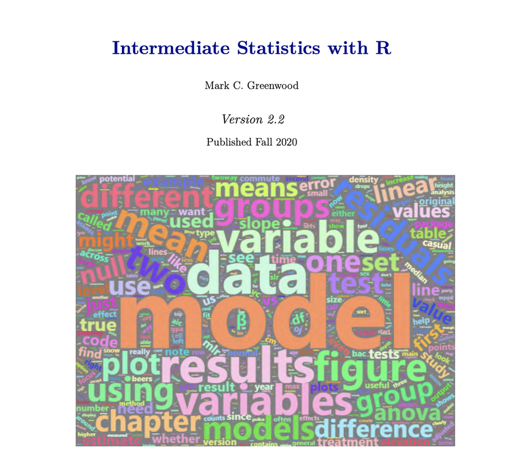

https://atheobold.github.io/Greenwood_Book/

### Additional Materials

[figure not shown]

Çetinkaya-Rundel, Diez, and Hardin, **Introduction to Statistics with Randomization and Simulation**. https://openintro-ims.netlify.app/

[figure not shown]

Ismay & Kim, **Modern Dive: Statistical Inference via Data Science**. https://moderndive.com.

## Required Technology

- `R` is the statistical software we will be using in this course (https://cran.r-project.org/).
- RStudio (https://rstudio.com/products/rstudio/download/) is the most popular way to interact with the `R` software. To function correctly, RStudio needs `R` and therefore both need to be installed on your computer.
- If you are unable to install `R` and RStudio on your computer, you can use Cal Poly’s Virtual Computer Labs (https://tech.calpoly.edu/virtual-computer-labs-appstream). RStudio is available in the “Computational” labs. You will need to use a two-factor log-in (Cal Poly + Duo Mobile), which will then take you to a list of applications. When you select RStudio, the page will load for 2-4 minutes (😢). Once you are in, you can work in RStudio the same way you would on your laptop, *except* everything you make during a session **cannot be accessed later**.
- Canvas will be used for weekly course discussions and lab submissions
- Zoom will be used for weekly (synchronous) course meetings, office hours, and small group collaborations

## Welcoming Classroom

I value diversity, social justice, inclusion and equity in this (and every) class. I hold the fundamental belief that everyone is fully capable of engaging in and mastering material. There is more than one way to address a statistical problem, and our learning will be richer by remaining open to different ideas, by rejecting stereotypes, and being aware of–in order to minimize–our biases. I look forward to getting to know you all as individuals and as a learning community.

## Course Description and Learning Objectives

*Catalog Description*: Analysis of variance and regression analysis for students not majoring in statistics or mathematics. Includes one-way classification, randomized blocks, Latin squares, factorial designs, multiple regression, diagnostics, and model comparison. 4 lectures. Prerequisite: Stat 217, Stat 218, Stat 221 or Stat 312

*Expected Outcomes*:

- Identify, describe, and contrast different study designs:
  - observational studies
  - one-factor completely randomized designs
  - randomized complete block designs
  - factorial designs
- Analyze and interpret the results of analysis of variance (ANOVA) from different study designs, including multiple comparisons of means
- Analyze and interpret the results of simple linear regression models, and multiple linear regression models which use both quantitative and categorical predictor variables
- Describe the assumptions of the ANOVA and regression models and evaluate whether they are violated for a particular analysis.
- Describe Type I error, Type II error, and statistical power in context; discuss how different aspects of a study design will affect errors and power
- Identify potential ethical issues surrounding data collection and analysis
- Create thoughtful univariate, bivariate, and multivariate data visualizations to aid in the communication of statistical findings
- Carry out data wrangling tasks required to prepare data for analysis, including selecting variables, filtering observations, and mutating variables
- Understand the importance of reproducibility in scientific research, and collaborate in groups to create a reproducible statistical report

#### COVID-19 Addendum

I understand and appreciate the strange world we find ourselves living in today. Surrounded by a global pandemic, civil unrest, and an upcoming presidential election, many of us find ourselves overwhelmed, frustrated, confused, and sad. I appreciate all of these outside forces you are navigating, and will do my best to monitor the pace of our course so that no one feels left behind. Yes, this may mean that we may not hit every learning outcome. Instead, it is of utmost importance to me that you leave this course with an appreciation for the complexities involved in building a statistical model, grasp of the importance of good experimental design, and that you participate in group conversations about statistical reasoning and problem solving.

## Course Components

Canvas will be your main resource for asynchronous course materials:

- class notes
- lecture videos
- discussion posts
- data sets
- lab assignments
- group projects
- software resources

Zoom will be the main resource for synchronous course participation:

- course meetings
- small group collaborations

### Communication

Every Monday there will be an announcement on Canvas letting you know what is due over the next week, and the material we will be covering.

We will use discussion channels in Canvas to manage questions and responses regarding course content. Please **do not** send an email about homework questions or questions about the course material. It will be very helpful to others in the course to see the questions you have and the responses to those questions. I will try to answer any questions posted to Canvas within 12 hours. If you think you can answer another student’s question, please respond. I will correct any inaccurate responses. If you have a question about something, the discussion channels are the first place you should go. Personal matters may be sent via email.

Generally, I will work **either** Saturday or Sunday each weekend, and will work from approximately 8am to 5pm (PST) during the week. I will attempt to respond to emails in 24 hours, but emails sent on a Saturday night may not be responded to until Monday morning. If you don’t hear back from me in 48 hours, assume I did not receive your email and resend it!

### Weekly Schedule

Each week in STAT 313 will, for the most part, look something like this:

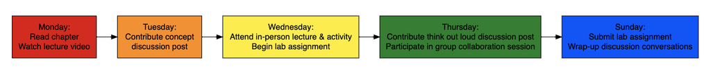

### Readings and Videos

For this course, we’ll be using a “flipped class” format. This means I will provide you with readings, pre-recorded videos, and guided tutorials for you to watch, read, and do on your own time. You are expected to complete the readings, watch the videos, and/or attempt the tutorials **before** our weekly in-person class meetings.

### Course Meetings

The weekly course meetings will consist of group discussions and interactive lab activities. You will be randomly spit into breakout rooms where you will work with others to accomplish the activity.

### Discussion Forums, Active Participation, & Tasks

You will be expected to regularly participate in online discussion forums on Canvas. Every two weeks you will be randomly assigned to a group of 3-4 students, whom you will converse with when completing the week’s required posts. You will be expected to complete the following discussion posts each week:

1. “concept” post discussing and/or asking questions about the concepts covered in the videos/reading
2. “thinking out loud” post describing your *rough-draft* thinking about a designated problems

The “concept post” should be done as you are completing the reading and/or watching the video. The “thinking out loud” post should be done after the course meeting, while you are working through the week’s lab. You are expected to continue the conversation by responding to *at least* two other student’s posts and addressing any comments made to your original thread. When responding to members of your group, respond first to those who have not yet received any replies. Each post cannot have more than two responses until every post has has had a response.

Scores for contributions to discussion forums will be based on the following rubric:

| Score | Justification |
| --- | --- |
| 4 | **Substantial Contributions** – Contributions to discussions that reflect thoughtfulness and move understanding of content forward. These contributions can include unique solution strategies, making c… |
| 3 | **Supportive Contributions** – Contributions to discussions that reflect agreement or disagreement with others’ contributions without moving understanding of content forward OR offer summaries of othe… |
| 0 | **No Contributions** – Does not contribute, includes statements such as “I agree” or “That’s interesting.” |
| 0 | **Negligence** – Contributions restrict or squelch the ability of others to contribute to the learning environment. |

### Work Sessions

There will be 1 small group collaboration held **each week** on Zoom, where up to 4 students will work together on a task for the week. Each student will sign up to attend **at least one** small group collaboration during the quarter. Each session will be held on Zoom, and recorded for all other students to watch and reflect. Scores for this portion of the course will be allocated based on attendance and by using the rubric for discussion forums (see above).

### Knowledge Checks

Each small group collaboration will be accompanied by a short knowledge check for students to reflect on what they learned during the collaboration or through watching the video.

### Homework/Labs

Labs will be assigned regularly based on content covered and in preparation for upcoming activities. Problem sets will consist of explorations of concepts from the week’s reading, and will often require `R` for completion.

You are expected to submit your lab solutions electronically to Canvas as **both** an HTML and an RMarkdown document. Not every item will be scored; however, feedback on representative items will be given for each assignment.

### Projects

There will be 2 projects throughout the quarter, where you will be asked to apply the statistical concepts you have learned in the context of real data. Each of these projects will be done in groups of 3-4. More details will be provided during class.

### (Oral) Exams

There will be 2 assessments designed for students to demonstrate their understanding of content covered during the course. Each unit assessment will be held virtually as an individual oral exam. These exams will require for you to talk through a set of open-response questions, demonstrating your understanding of the concepts. Each exam will follow the submission of the group projects, with the first occurring approximately halfway through the course and the second taking place during finals week.

## Course Assessment

Your grade in STAT 313 will contain the following components.

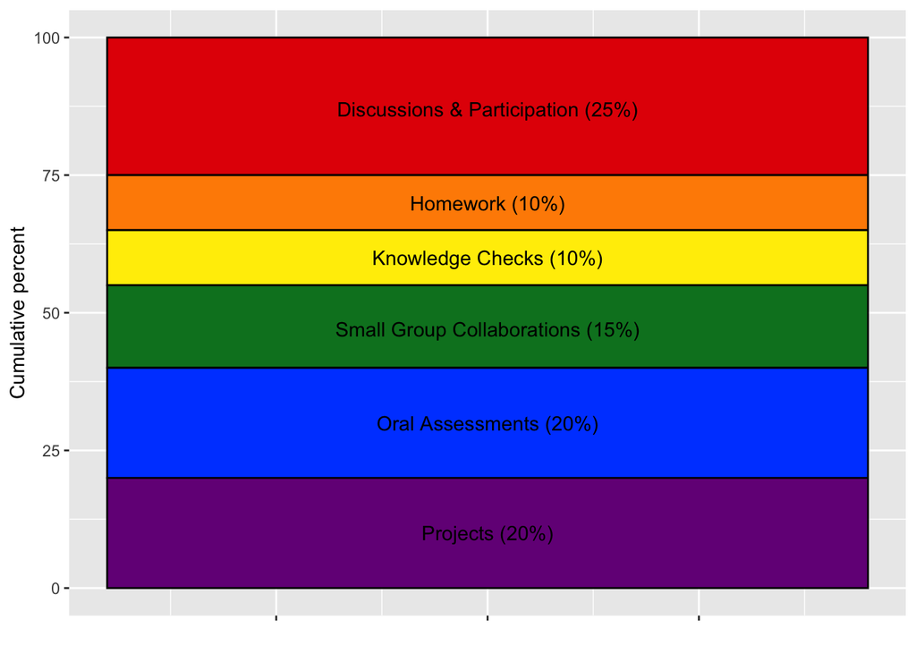

### Grading

I expect that you will approach each homework assignment seriously, investing the necessary time and energy to prepare your responses. All items will be scored using the following four-point scale.

| Score | Justification |
| --- | --- |
| 4 | **Excellent** – Outstanding work that exhibits comprehensive and thoughtful understanding of the content of the assignment. Errors do not occur in the assignment. |
| 3 | **Good** – Work reflects a solid understanding of the content of the assignment. Work may not exhibit original perspectives. Several errors may occur in the assignment. |
| R | **Redo (Required)** – Work satisfies the requirements of the assignment while missing the spirit of the assignment. May be an incomplete rendering of the assignment. The work may contain inconsistenci… |
| 1 | **Poor** – The work shows a lack of understanding of the assignment. |
| 0 | **No credit** – The problem was not seriously attempted. |

Each homework assignment will receive a score that reflects the average points-per-question. For example, suppose your homework assignment has four questions and you receive the following scores on each problem: 3, 4, 3, and 4. Then, your overall score is (3+4+3+4)/4 = 3.5. Suppose you received the following scores (3, 4, 3, and R). Then, your initial overall score is (3+4+3+0)/4 = 2.5 (Redo 1). Note: If you have a redo on an assignment, a total score of 0 will be entered into the gradebook for that assignment until the redo has been completed.

Problems marked with an “R” **must** be redone and returned within **two days** of receiving the assignment back. Late redos receive a zero but still must be turned in to fulfill the spirit of redos. Work successfully redone (on time) will receive a maximum grade of 3. When you submit your redo, label the revision with your name, the assignment number, and if applicable, the page and problem number. It is possible to have a redo on a redo.

**Do not** interpret 3/4 as equivalent to a grade of 75%. This rubric is intended to be about the quality of your work, not the percentage of points earned. It is likely that students consistently scoring “Good” on this rubric will earn at least a B- in the course.

Letter grades will be assigned according to the following minimums: 3.75 (A), 3.0 (B-), 2.85 (C), below 2.85 (C-, D, or F).

If you have more than three “0” grades due to turning assignments in late, un-revised “Rs,” class absences resulting in “0” participation grade, or missed assignments, the highest grade you will earn for the class is a C-.

## Late Work Policy

Homework and redos are expected to be submitted on time. However, every student will be permitted to submit **one** assignment 24 hours late without question. You do not need to contact me to use this allowance, but if you find yourself in a position where you have use this allowance and you cannot complete the assignment by the due date, **you are expected to email me**. Once you email me, we can work together to find a deadline that is fair to both you and other students. If I do not hear from you, I will take a 5% reduction in score for every day an assignment is late, up to four days

You are also expected to participate in the week’s discussions in a timely manner. You will not be able to see your group’s posts until you have created a post of your own. Thus, if you neglect to post anything until Friday, you will only have until Sunday night to create thoughtful responses to the other posts from your group. If you find that you are unable to participate in the week’s discussion posts in a timely manner, **please contact me**. Once you contact me, we can create a timeline that will both allow for you to participate in the discussions and allow for members of your group to receive feedback from you.

## Time Dedication Expectations

In a face-to-face lecture course like STAT 313, each unit of credit represents one hour of in class instruction and approximately 2 hours of work outside of class per week. This equals approximately 9 hours of student work for a 3-unit class: 3 hours in-class and approximately 6 hours outside of class each week.

For a 3-unit asynchronous, I expect you to work approximately 1-3 hours per day (Mon-Friday), plus another 3-6 hours over the weekend (Sat-Sun). I will attempt to follow this guideline as I develop and post materials for the course, but please reach out if the time you are spending on the materials for this course falls far beyond these time guidelines!

## Behavioral Expectations

This course will use group work and classroom activities to better engage your understanding of the material. The environment for these discussions and activities is expected to adhere to ground rules, so that we create an open space where everyone feels welcome and supported, and comfortable with voicing their opinion.

By participating in this community, students accept to abide by the classroom Code of Conduct and accept the procedures by which any Code of Conduct incidents are resolved. Any form of behavior to exclude, intimidate, or cause discomfort is a violation of the Code of Conduct. In order to foster a positive and professional learning environment we encourage the following kinds of behaviors in all platforms and events:

- use welcoming and inclusive language
- everyone participates and no one dominates
- listen to understand
- share airtime
- one speaker at a time
- disagree with respect
- be respectful of different viewpoints and experiences
- all ideas are valid
- gracefully accept constructive criticism
- treat everything you hear as an opportunity to learn and grow
- seek common ground and understanding

## Collaboration

Students are expected to collaborate on work in this class, but all work turned in must be completed by the individual receiving a grade. You should discuss your ideas with classmates, discuss statistical questions with classmates, and exchange completed problems for peer-review with classmates. You must not copy solutions from classmates or others or use solutions that are not your own. If you are unsure about the degree of collaboration that is acceptable, please ask the professor for clarification. Cheating will not be tolerated. Academic misconduct will result in a minimum penalty of a grade of F on the assignment.

## Computer Assistance - Cal Poly Cares

If you are experiencing financial hardship and are unable to afford the technology you need to be academically successful, you can apply to Cal Poly Cares for assistance. Https://basicneeds.calpoly.edu/calpolycares or email financialaid@calpoly.edu to request information about how you can apply for funding to help cover the cost of purchasing a computer.

## Plagiarism

Paraphrasing or quoting another’s work without citing the source is a form of academic misconduct. Even inadvertent or unintentional misuse or appropriation of another’s work (such as relying heavily on source material that is not expressly acknowledged) is considered plagiarism. If you have any questions about using and citing sources, you are expected to ask for clarification.

## Illnesses

In the event of illness, you should email me if you will miss class deadlines due to illness as soon as practical.

### COVID-19 Symptoms

COVID-19 affects different people in different ways, but we all need to do our part to prevent the spread of COVID-19. Taking these preventative steps, as well as monitoring your health and staying home if you are feeling unwell, will help protect the safety of the Cal Poly community and beyond:

- **Cover Your Face**: You are required to wear a mask or face coverings in most public settings.
- **Keep a Distance**: Avoid close contact and remain at least six feet away from others.
- **Clean and Disinfect**: Wash your hands often and disinfect frequently touched surfaces.

## Americans with Disabilities Act

If you have a documented disability and would like to discuss academic accommodations, please contact me before the third week of class.

## Important University Dates

| Date | Day | Event |
| --- | --- | --- |
| September 14 | Monday | Fall term classes begin |
| September 23 | Wednesday | Last day to drop classes |
| September 25 | Friday | End of second week |
| October 2 | Friday | End of third week - Census date |
| October 30 | Friday | End of seventh week, last day to withdraw from a course |
| November 11 | Wednesday | Academic holiday - Veterans Day Observed |
| November 24 | Tuesday | Last day of instruction, Last day to decide C/NC |
| November 25 - 29 | Wednesday-Sunday | Thanksgiving holiday |
| November 30 | Monday | Final Exam |

**Note:** The final exam times are as follows: 7:10 - 10:00 am for Section 01, 10:10 - 1:00 pm for Section 02